# Peer graded assignment: Course project 1

1. Set working directory, read data and load libraries used.

```r
setwd("C:/Users/Rafael/Desktop/Rafael Balde/Coursera Data Science")

activity <- read.csv("activity.csv", header = T, sep = ",")

library(dplyr)
library(ggplot2)
```

2. Aggregate by date, sum steps and plot a histogram of the daily steps.

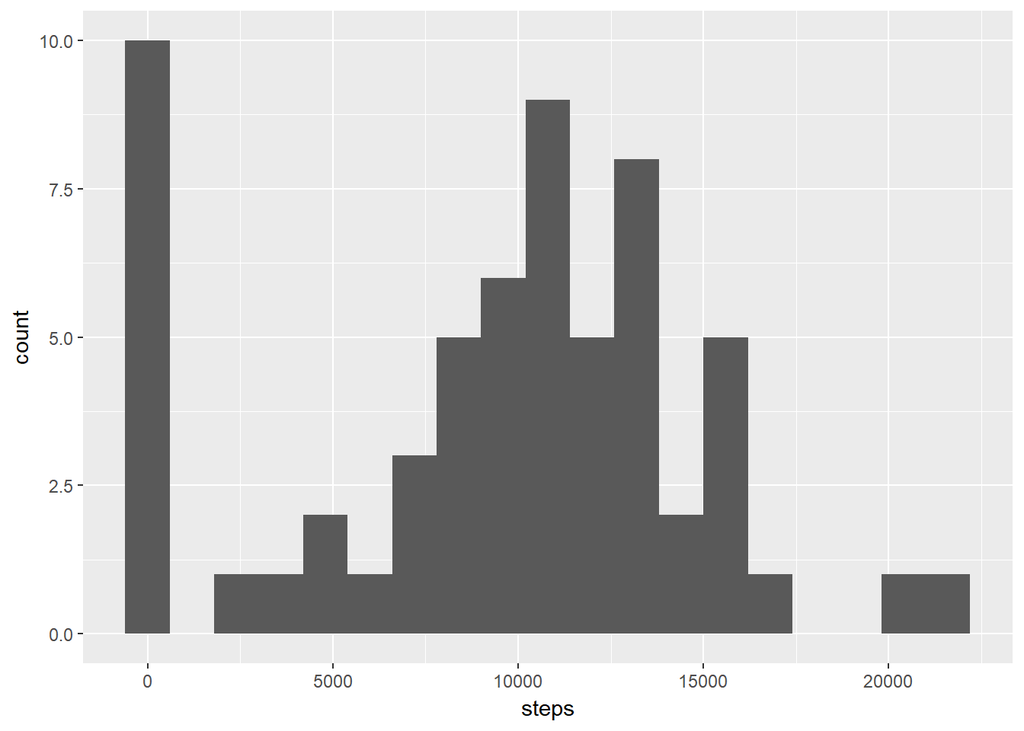

```r
daily.steps <- activity %>% group_by(date) %>% summarise(steps = sum(steps, na.rm =T))

ggplot(daily.steps, aes(x = steps)) + geom_histogram(binwidth = 1200 )
```

3. Compute mean and median daily steps.

```r
summary(daily.steps$steps)
```

```
##    Min. 1st Qu.  Median    Mean 3rd Qu.    Max.
##       0    6778   10395    9354   12811   21194
```

4. Aggregate by interval, and plot time series of the average number of steps for each 5 minute interval.

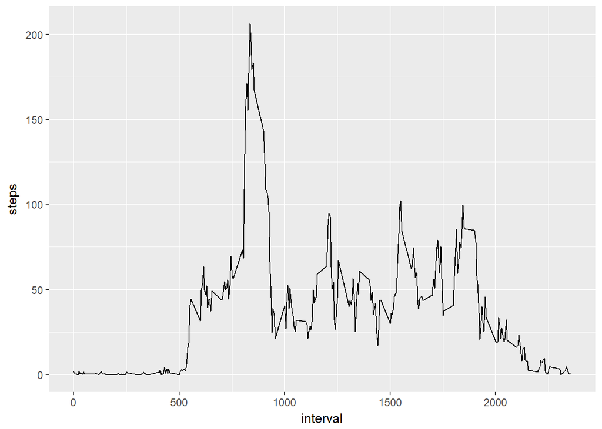

```r
intra.day.steps <- activity %>% group_by(interval) %>% summarise(steps = mean(steps, na.rm = T))

ggplot(intra.day.steps, aes(interval, steps)) + geom_line()
```

5. Find the interval with the maximum average number of steps.

```r
which.max(intra.day.steps$steps)
```

```
## [1] 104
```

The result is row 104, which corresponds to the minute 835.

6. Strategy for imputing missing values.

```r
#total number of NA values
sum(is.na(activity$steps))
```

```
## [1] 2304
```

```r
#compute summary statistics to see which is the best substitute for NAs
interval.stats <- activity %>%
  group_by(interval) %>%
  summarise(Steps.min = min(steps, na.rm = T),
  Steps.max = max(steps, na.rm = T),
  steps.mean = mean(steps, na.rm = T),
  steps.median = median(steps, na.rm = T),
  steps.sd = sd(steps, na.rm = T),
  steps.IQR = IQR(steps, na.rm = T))
```

The median for most intervals is 0. Therefore the mean is the best guess for the NA values.

```r
#create a lookup table for the average number of steps per interval
NA.lookup <- activity %>%
  group_by(interval) %>%
  summarise(steps.guess = mean(steps, na.rm = T))

#change the NA values for the interval mean
activity.imputed <- activity %>%
  left_join(NA.lookup, by = "interval") %>%
  mutate(steps = ifelse(is.na(steps), steps.guess, steps)) %>%
  select(-steps.guess)
```

7. Aggregate the values and plot new histogram.

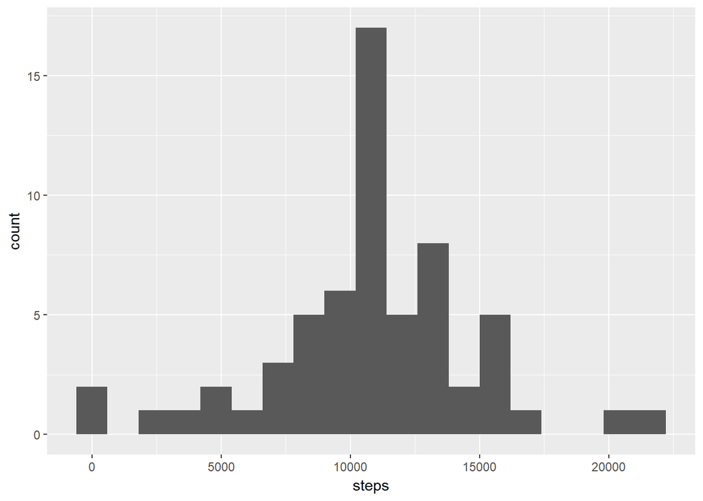

```r
daily.steps.2 <- activity.imputed %>% group_by(date) %>% summarise(steps = sum(steps))

ggplot(daily.steps.2, aes(x = steps)) + geom_histogram(binwidth = 1200 )
```

The result of the imputation is a decrease in the number of days which had 0 average steps. As a consequence, most of the counts went to a number of steps close to the mean…

Which now is.

```r
summary(daily.steps.2$steps)
```

```
##    Min. 1st Qu.  Median    Mean 3rd Qu.    Max.
##      41    9819   10766   10766   12811   21194
```

8. For the weekday/weekend analysis, we will first add a variable for which day of the week the observation is from.

```r
activity.imputed$date <- as.Date(activity.imputed$date)

activity.imputed <- activity.imputed %>%
  mutate(day = weekdays(activity.imputed$date))
```

Using stringr, we will look for a portuguese word that is only contained in weekdays. Then, we will coerce it to a factor, and aggregate by the intervals.

```r
library(stringr)

activity.imputed$day <- ifelse(str_detect(activity.imputed$day, "feira"), "weekday", "weekend")

activity.imputed$day <- as.factor(activity.imputed$day)

intra.day.2 <- activity.imputed %>% group_by(interval) %>% summarise(steps = mean(steps))
```

Now we plot the time series for weekdays and weekends.

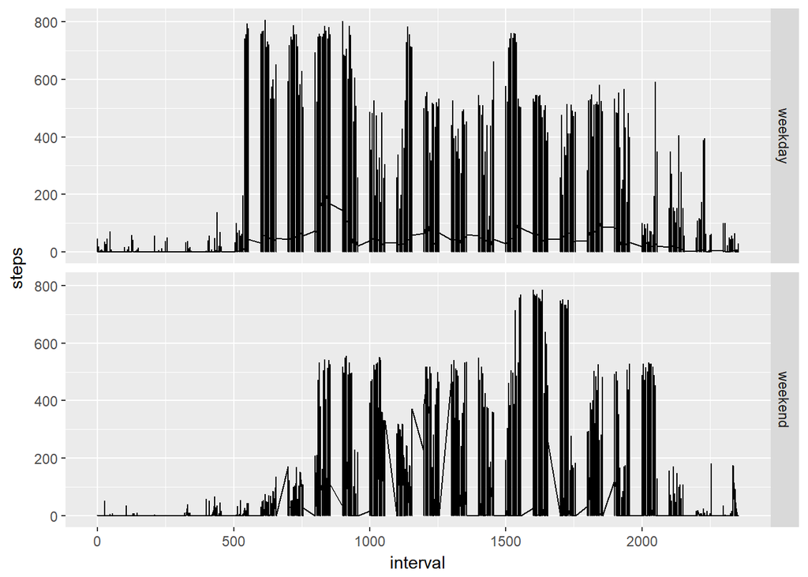

```r
ggplot(activity.imputed, aes(interval, steps)) + geom_line() + facet_grid(day~.)
```

The results show that the subject is more active earlier in the day during the week, and more active later in the day on weekends. It seems that he or she likes to party.